# Cyclistic Users

Natalia Romanini

2023-11-06

## Usuarios Cyclistic

**Tarea:**

- Determinar las diferencias entre los usuarios que son miembros de la aplicacién, a través de una subscripción, de aquellos que son usuarios ocasionales

### Data disponible

Se solicita se usen los 12 últimos meses de registro de los usuarios, obtenidos desde el siguiente enlace: https://divvy-tripdata.s3.amazonaws.com/index.html Al descargar los archivos, son 12 carpetas en .zip y cada una contiene un mes de registros, se descomprimen las carpetas y se renombra cada uno de los archivos .csv a fin de comenzar a trabjar con ellos desde R Studio por la magnitud y peso de la data

### Preparamos nuestro espacio de trabajo

Creamos una carpeta que contiene 12 archivos .csv y para poder importarlos, ordenarlos y limpiarlos y luego trabajar con ellos y realizar visualizaciones, instalamos y llamamos las siguientes librerias.

```r
install.packages("tidyverse")
library(tidyverse)
library(dplyr)
install.packages("gglopt2")
```

```r
library(ggplot2)
install.packages("geosphere")
library(geosphere)
library(wesanderson)


month1 <- read.csv('C:/Users/natal/OneDrive/Documents/bike_data/month1_oct2022.csv')
month2 <- read.csv('C:/Users/natal/OneDrive/Documents/bike_data/month2_nov2022.csv')
month3 <- read.csv('C:/Users/natal/OneDrive/Documents/bike_data/month3_dic2022.csv')
month4 <- read.csv('C:/Users/natal/OneDrive/Documents/bike_data/month4_ene2023.csv')
month5 <- read.csv('C:/Users/natal/OneDrive/Documents/bike_data/month5_feb2023.csv')
month6 <- read.csv('C:/Users/natal/OneDrive/Documents/bike_data/month6_mar2023.csv')
month7 <- read.csv('C:/Users/natal/OneDrive/Documents/bike_data/month7_abr2023.csv')
month8 <- read.csv('C:/Users/natal/OneDrive/Documents/bike_data/month8_may2023.csv')
month9 <- read.csv('C:/Users/natal/OneDrive/Documents/bike_data/month9_jun2023.csv')
month10 <- read.csv('C:/Users/natal/OneDrive/Documents/bike_data/month10_jul2023.csv')
month11 <- read.csv('C:/Users/natal/OneDrive/Documents/bike_data/month11_ago2023.csv')
month12 <- read.csv('C:/Users/natal/OneDrive/Documents/bike_data/month12_sep2023.csv')
```

(las rutas mostradas aqui son de PC y de archivos en un disco local)

### Revisando la data, sus columnas y tipos de datos.

- Se revisan las columnas de 3 archivos.

```r
colnames(month1)
```

```
##  [1] "ride_id"            "rideable_type"      "started_at"
##  [4] "ended_at"           "start_station_name" "start_station_id"
##  [7] "end_station_name"   "end_station_id"     "start_lat"
## [10] "start_lng"          "end_lat"            "end_lng"
## [13] "member_casual"
```

```r
colnames(month6)
```

```
##  [1] "ride_id"            "rideable_type"      "started_at"
##  [4] "ended_at"           "start_station_name" "start_station_id"
##  [7] "end_station_name"   "end_station_id"     "start_lat"
## [10] "start_lng"          "end_lat"            "end_lng"
## [13] "member_casual"
```

```r
colnames(month12)
```

```
##  [1] "ride_id"            "rideable_type"      "started_at"
##  [4] "ended_at"           "start_station_name" "start_station_id"
##  [7] "end_station_name"   "end_station_id"     "start_lat"
## [10] "start_lng"          "end_lat"            "end_lng"
## [13] "member_casual"
```

- Coinciden en la cantidad de columnas y nombres, ahora revisemos el tipo de dato

```r
glimpse(month3)
```

```
## Rows: 181,806
## Columns: 13
## $ ride_id            <chr> "65DBD2F447EC51C2", "0C201AA7EA0EA1AD", "E0B148CCB3…
## $ rideable_type      <chr> "electric_bike", "classic_bike", "electric_bike", "…
## $ started_at         <chr> "2022-12-05 10:47:18", "2022-12-18 06:42:33", "2022…
## $ ended_at           <chr> "2022-12-05 10:56:34", "2022-12-18 07:08:44", "2022…
## $ start_station_name <chr> "Clifton Ave & Armitage Ave", "Broadway & Belmont A…
## $ start_station_id   <chr> "TA1307000163", "13277", "TA1306000015", "KA1503000…
## $ end_station_name   <chr> "Sedgwick St & Webster Ave", "Sedgwick St & Webster…
## $ end_station_id     <chr> "13191", "13191", "13016", "13134", "13288", "KA150…
## $ start_lat          <dbl> 41.91824, 41.94011, 41.88592, 41.83846, 41.89595, 4…
## $ start_lng          <dbl> -87.65711, -87.64545, -87.65113, -87.63541, -87.667…
## $ end_lat            <dbl> 41.92217, 41.92217, 41.89435, 41.88137, 41.92008, 4…
## $ end_lng            <dbl> -87.63889, -87.63889, -87.62280, -87.67493, -87.677…
## $ member_casual      <chr> "member", "casual", "member", "member", "casual", "…
```

```r
glimpse(month8)
```

```
## Rows: 604,827
## Columns: 13
## $ ride_id            <chr> "0D9FA920C3062031", "92485E5FB5888ACD", "FB144B3FC8…
## $ rideable_type      <chr> "electric_bike", "electric_bike", "electric_bike", …
## $ started_at         <chr> "2023-05-07 19:53:48", "2023-05-06 18:54:08", "2023…
## $ ended_at           <chr> "2023-05-07 19:58:32", "2023-05-06 19:03:35", "2023…
## $ start_station_name <chr> "Southport Ave & Belmont Ave", "Southport Ave & Bel…
## $ start_station_id   <chr> "13229", "13229", "13162", "13196", "TA1308000047",…
## $ end_station_name   <chr> "", "", "", "Damen Ave & Cortland St", "Southport A…
## $ end_station_id     <chr> "", "", "", "13133", "13229", "TA1306000029", "1343…
## $ start_lat          <dbl> 41.93941, 41.93948, 41.85379, 41.89456, 41.95708, 4…
## $ start_lng          <dbl> -87.66383, -87.66385, -87.64672, -87.65345, -87.664…
## $ end_lat            <dbl> 41.93000, 41.94000, 41.86000, 41.91598, 41.93948, 4…
## $ end_lng            <dbl> -87.65000, -87.69000, -87.65000, -87.67733, -87.663…
## $ member_casual      <chr> "member", "member", "member", "member", "member", "…
```

```r
glimpse(month11)
```

```
## Rows: 771,693
## Columns: 13
## $ ride_id            <chr> "903C30C2D810A53B", "F2FB18A98E110A2B", "D0DEC7C94E…
## $ rideable_type      <chr> "electric_bike", "electric_bike", "electric_bike", …
## $ started_at         <chr> "2023-08-19 15:41:53", "2023-08-18 15:30:18", "2023…
## $ ended_at           <chr> "2023-08-19 15:53:36", "2023-08-18 15:45:25", "2023…
## $ start_station_name <chr> "LaSalle St & Illinois St", "Clark St & Randolph St…
## $ start_station_id   <chr> "13430", "TA1305000030", "TA1305000030", "KA1504000…
## $ end_station_name   <chr> "Clark St & Elm St", "", "", "", "", "", "", "", ""…
## $ end_station_id     <chr> "TA1307000039", "", "", "", "", "", "", "", "", "",…
## $ start_lat          <dbl> 41.89072, 41.88451, 41.88498, 41.90310, 41.88555, 4…
## $ start_lng          <dbl> -87.63148, -87.63155, -87.63079, -87.63467, -87.632…
## $ end_lat            <dbl> 41.90297, 41.93000, 41.91000, 41.90000, 41.89000, 4…
## $ end_lng            <dbl> -87.63128, -87.64000, -87.63000, -87.62000, -87.680…
## $ member_casual      <chr> "member", "member", "member", "member", "member", "…
```

##### Al ver que todos los archivos comparten el mismo tipo de información, podemos unirlos en uno solo.

```r
all_trips<-bind_rows(month1, month2, month3, month4, month5, month6, month7, month8, month9, month10, month11, month12)
```

#### Modifiquemos algunos nombres de columnas y sus características y creemos una columna que cuente el tiempo de cada viaje y otra que nos señale el dia de esos viajes

```r
all_trips <-rename(all_trips, trips_id = ride_id, start_time = started_at,
                   end_time = ended_at, usertype = member_casual)
```

**Y revisemos nuestro dataframe**

```r
colnames(all_trips)
```

```
##  [1] "trips_id"           "rideable_type"      "start_time"
##  [4] "end_time"           "start_station_name" "start_station_id"
##  [7] "end_station_name"   "end_station_id"     "start_lat"
## [10] "start_lng"          "end_lat"            "end_lng"
## [13] "usertype"
```

```r
nrow(all_trips)
```

```
## [1] 5674399
```

```r
dim(all_trips)
```

```
## [1] 5674399      13
```

```r
head(all_trips)
```

```
##           trips_id rideable_type          start_time            end_time
## 1 A50255C1E17942AB  classic_bike 2022-10-14 17:13:30 2022-10-14 17:19:39
## 2 DB692A70BD2DD4E3 electric_bike 2022-10-01 16:29:26 2022-10-01 16:49:06
## 3 3C02727AAF60F873 electric_bike 2022-10-19 18:55:40 2022-10-19 19:03:30
## 4 47E653FDC2D99236 electric_bike 2022-10-31 07:52:36 2022-10-31 07:58:49
## 5 8B5407BE535159BF  classic_bike 2022-10-13 18:41:03 2022-10-13 19:26:18
## 6 A177C92E9F021B99 electric_bike 2022-10-13 15:53:27 2022-10-13 15:59:17
##          start_station_name start_station_id
## 1  Noble St & Milwaukee Ave            13290
## 2 Damen Ave & Charleston St            13288
## 3  Hoyne Ave & Balmoral Ave              655
## 4        Rush St & Cedar St     KA1504000133
## 5         900 W Harrison St            13028
## 6         900 W Harrison St            13028
##                       end_station_name end_station_id start_lat start_lng
## 1            Larrabee St & Division St   KA1504000079  41.90068 -87.66260
## 2             Damen Ave & Cullerton St          13089  41.92004 -87.67794
## 3             Western Ave & Leland Ave   TA1307000140  41.97988 -87.68190
## 4 Orleans St & Chestnut St (NEXT Apts)            620  41.90227 -87.62769
## 5                    Adler Planetarium          13431  41.87475 -87.64981
## 6             Loomis St & Lexington St          13332  41.87472 -87.64983
##    end_lat   end_lng usertype
## 1 41.90349 -87.64335   member
## 2 41.85497 -87.67570   casual
## 3 41.96640 -87.68870   member
## 4 41.89820 -87.63754   member
## 5 41.86610 -87.60727   casual
## 6 41.87219 -87.66150   casual
```

```r
str(all_trips)
```

```
## 'data.frame':    5674399 obs. of  13 variables:
##  $ trips_id          : chr  "A50255C1E17942AB" "DB692A70BD2DD4E3" "3C02727AAF60F873" "47E653FDC2D99236" ...
##  $ rideable_type     : chr  "classic_bike" "electric_bike" "electric_bike" "electric_bike" ...
##  $ start_time        : chr  "2022-10-14 17:13:30" "2022-10-01 16:29:26" "2022-10-19 18:55:40" "2022-10-31 07:52:36" ...
##  $ end_time          : chr  "2022-10-14 17:19:39" "2022-10-01 16:49:06" "2022-10-19 19:03:30" "2022-10-31 07:58:49" ...
##  $ start_station_name: chr  "Noble St & Milwaukee Ave" "Damen Ave & Charleston St" "Hoyne Ave & Balmoral Ave" "Rush St & Cedar St" ...
##  $ start_station_id  : chr  "13290" "13288" "655" "KA1504000133" ...
##  $ end_station_name  : chr  "Larrabee St & Division St" "Damen Ave & Cullerton St" "Western Ave & Leland Ave" "Orleans St & Chestnut St (NEXT Apts)" ...
##  $ end_station_id    : chr  "KA1504000079" "13089" "TA1307000140" "620" ...
##  $ start_lat         : num  41.9 41.9 42 41.9 41.9 ...
##  $ start_lng         : num  -87.7 -87.7 -87.7 -87.6 -87.6 ...
##  $ end_lat           : num  41.9 41.9 42 41.9 41.9 ...
##  $ end_lng           : num  -87.6 -87.7 -87.7 -87.6 -87.6 ...
##  $ usertype          : chr  "member" "casual" "member" "member" ...
```

```r
summary(all_trips)
```

```
##    trips_id         rideable_type       start_time          end_time
##  Length:5674399     Length:5674399     Length:5674399     Length:5674399
##  Class :character   Class :character   Class :character   Class :character
##  Mode  :character   Mode  :character   Mode  :character   Mode  :character
##
##
##
##
##  start_station_name start_station_id   end_station_name   end_station_id
##  Length:5674399     Length:5674399     Length:5674399     Length:5674399
##  Class :character   Class :character   Class :character   Class :character
##  Mode  :character   Mode  :character   Mode  :character   Mode  :character
##
##
##
##
##    start_lat       start_lng         end_lat         end_lng
##  Min.   :41.63   Min.   :-87.94   Min.   : 0.00   Min.   :-88.16
##  1st Qu.:41.88   1st Qu.:-87.66   1st Qu.:41.88   1st Qu.:-87.66
##  Median :41.90   Median :-87.64   Median :41.90   Median :-87.64
##  Mean   :41.90   Mean   :-87.65   Mean   :41.90   Mean   :-87.65
##  3rd Qu.:41.93   3rd Qu.:-87.63   3rd Qu.:41.93   3rd Qu.:-87.63
##  Max.   :42.07   Max.   :-87.46   Max.   :42.18   Max.   :  0.00
##                                   NA's   :6642    NA's   :6642
##    usertype
##  Length:5674399
##  Class :character
##  Mode  :character
##
##
##
##
```

```r
n_distinct(all_trips$usertype)
```

```
## [1] 2
```

Todo parece correcto.

Busquemos **valores faltantes** para conocer si afectaran nuestro analisis y deben retirar o son despreciables para el objetivo

```r
trips_na <- all_trips %>% filter(if_any(everything(), is.na))
```

Podemos agrupar por tipo de usuario para revisar

```r
trips_na %>% group_by(usertype) %>%
  count(usertype)
```

```
## # A tibble: 2 × 2
## # Groups:   usertype [2]
##   usertype     n
##   <chr>    <int>
## 1 casual    5671
## 2 member     971
```

Nos damos cuenta que hay 6642 registros que no tienen informacion de estacion de llegada y por tanto tampoco de su punto geografico y que esto principalmente afecta a usuarios “casual” pero la cantidad no es tanta en comparacion con la muestra total por lo que la podemos mantener, pero revisaremos si algo es anormal

```r
trips_na <- trips_na %>% mutate(trip_duration = difftime(as.POSIXct(end_time), as.POSIXct(start_time), units = "hours"))
mean(trips_na$trip_duration)
```

```
## Time difference of 46.53996 hours
```

El tiempo promedio de viaje es superior a 46 horas, lo que no parece razonable, por lo que ** eliminaremos esos registros ** y agregamos una columna de duracion de viaje.

### Últimas transformaciones de nuestro data frame.

Eliminemos las filas que no tiene informacion sobre el punto final del viaje y creemos una columna que determine la duracion de los viajes en horas

```r
all_trips_clean <- all_trips[complete.cases(all_trips), ]
all_trips_clean <- all_trips_clean %>% mutate(trip_duration = difftime(as.POSIXct(end_time), as.POSIXct(start_time), units = "hours"))
```

Para terminar las transformaciones del datafram, agregaremos una columna que nos señale la distancia que se recorrió en cada viaje y el dia de la semana en que se hizo

```r
all_trips_clean <- all_trips_clean %>% mutate(distance=distHaversine(matrix(c(start_lng,start_lat), ncol = 2), matrix(c(end_lng,end_lat), ncol=2)))

all_trips_clean <- all_trips_clean %>% mutate(weekday = wday(start_time, label = TRUE))
```

### Ahora podemos empezar a explorar los datos.

##### cuántos de los viajes los hicieron miembros y cuántos fueron hechos por usuarios casuales.(Nótese que no hay informacion para poder determinar si una persona determinada hizo uno o más viajes) Para eso, creamos una tabla.

```r
usertypecantidad <- all_trips_clean %>% group_by(usertype) %>%
  count(usertype)
```

Y ahora a esos números le podemos dar mas sentido e informacion para graficar y que nos muestre un porcentaje:

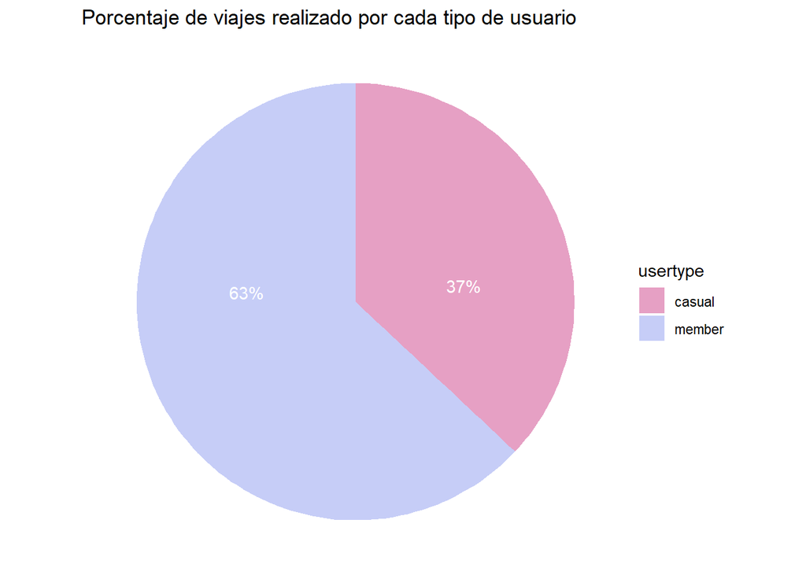

```r
usertypecantidad <- usertypecantidad %>% mutate(pct = paste(round(n/sum(usertypecantidad$n)*100), "%", sep =""))
usertypecantidad <-usertypecantidad %>% mutate(cantidad = round(n/sum(usertypecantidad$n)*100))
usertypecantidad <-usertypecantidad %>% mutate(pct_y = 100 - cantidad )

ggplot(usertypecantidad, aes(x = 1, y = cantidad, fill = usertype)) +
  geom_col(position = "stack", orientation = "x") +
  geom_text(aes(x=1, y = pct_y, label = pct), col="white", position = position_stack(vjust = 0.64))+
  coord_polar(theta = "y", direction = -1) +
  theme_void() + scale_fill_manual(values=wes_palette(n=2, name="GrandBudapest2")) + ggtitle("Porcentaje de viajes realizado por cada tipo de usuario")
```

#### Podemos comparar los tipos de bicicleta que usa cada tipo de usuario.

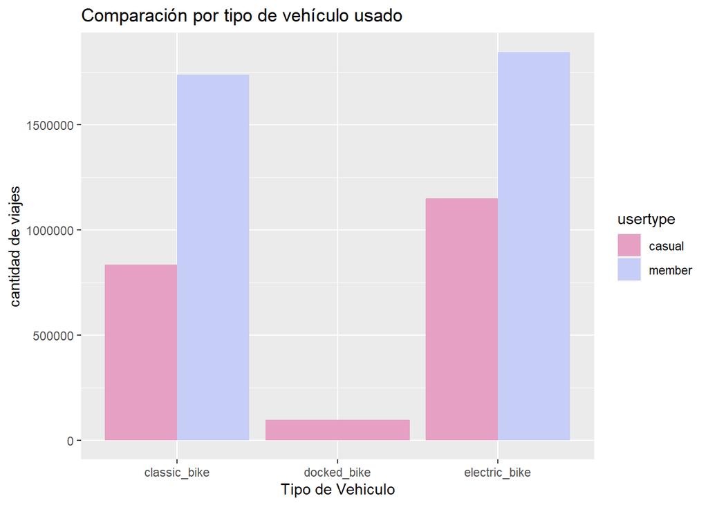

```r
ridetype <- all_trips_clean %>% group_by(rideable_type) %>%
  count(usertype)
ggplot(ridetype, aes(fill=usertype, y=n, x=rideable_type)) +
  geom_bar(position='dodge', stat="identity")+scale_fill_manual(values=wes_palette(n=2, name="GrandBudapest2")) + labs(x= "Tipo de Vehiculo", y ="cantidad de viajes") + ggtitle("Comparación por tipo de vehículo usado")
```

#### Sobre la distancia que recorre cada tipo de usuario

```r
distanciausuario <- all_trips_clean %>% group_by(usertype) %>%
  summarise(Mean_distance = mean(distance, na.rm=TRUE), Min_distance= min(distance, na.rm=TRUE), Max_distance = max(distance, na.rm=TRUE))

length(which(all_trips_clean$distance == 0))
```

```
## [1] 290942
```

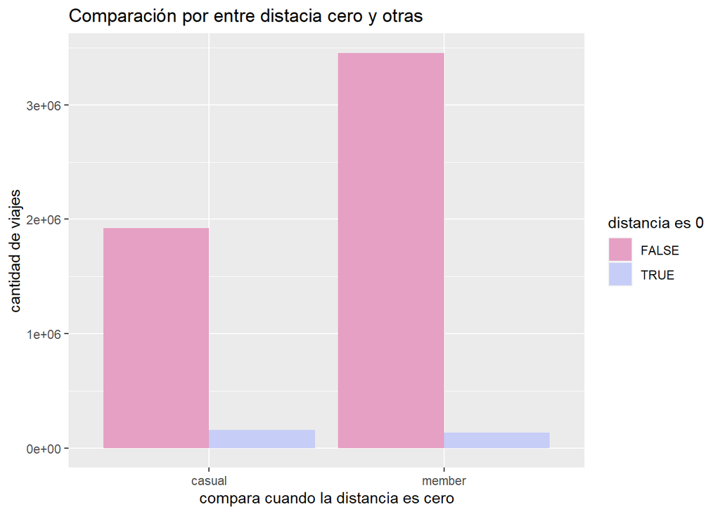

```r
distancia0 <-all_trips_clean %>% group_by(usertype) %>%
  count(distance == 0)
ggplot(distancia0, aes(x=usertype, y=n, fill = `distance == 0`)) +
  geom_bar(position='dodge', stat="identity")+scale_fill_manual(values=wes_palette(n=2, name="GrandBudapest2")) + labs(x= "compara cuando la distancia es cero", y ="cantidad de viajes", fill = "distancia es 0") + ggtitle("Comparación por entre distacia cero y otras")
```

#### Días en que se utiliza el servicio. agreguemos una columna con el dia

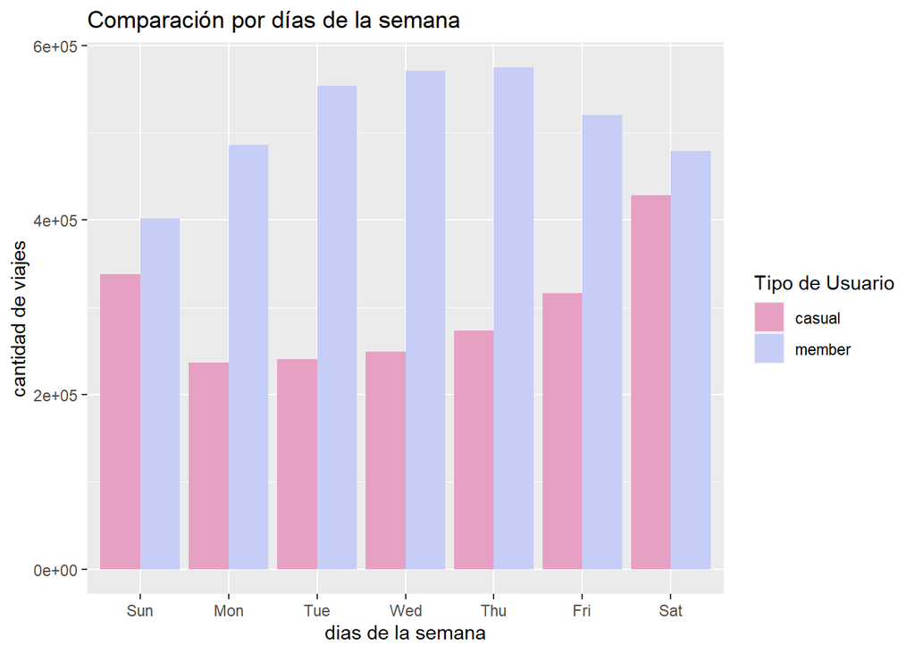

```r
weekdays <- all_trips_clean %>% group_by(usertype, weekday) %>%
  count(usertype)
ggplot(weekdays, aes(x = weekday, y = n, fill = usertype)) +
  geom_col(position = "dodge")+scale_fill_manual(values=wes_palette(n=2, name="GrandBudapest2")) + labs(x= "dias de la semana", y ="cantidad de viajes", fill = "Tipo de Usuario") + ggtitle("Comparación por días de la semana")
```

Se aprecia que los usuarios con membresia utilizan mas el servicio en dias de semana y los no miembros fines de semana.

## Recomendaciones

- Subir los precios para no miembros los fines de semana, a ver si se convierten en miembros
- Se necesitan datos de viajes por usuario para revisar la conveniencia económica efectiva de los usuarios sean miembros.
- Deberia revisarse la app para ver por que falla al guardar la informacion de punto de término del viaje